# Class 29

DATA1220-55, Fall 2024

Sarah E. Grabinski

2024-11-11

## Lab 02

- Open RStudio and start a new project in a folder called `lab02`
- Go to File > New File > R Script. Save the file as `lab02.R`.
- Download the file `nhanes.xlsx` from Canvas under Lab 1 or find it in your `lab01` project folder.

## Files View

[figure not shown]

## Importing a Dataset

[figure not shown]

## Importing Files - Excel

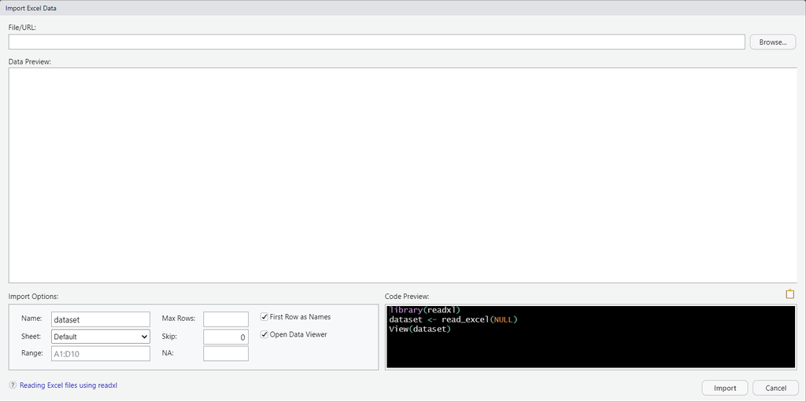

## Importing Files - Excel

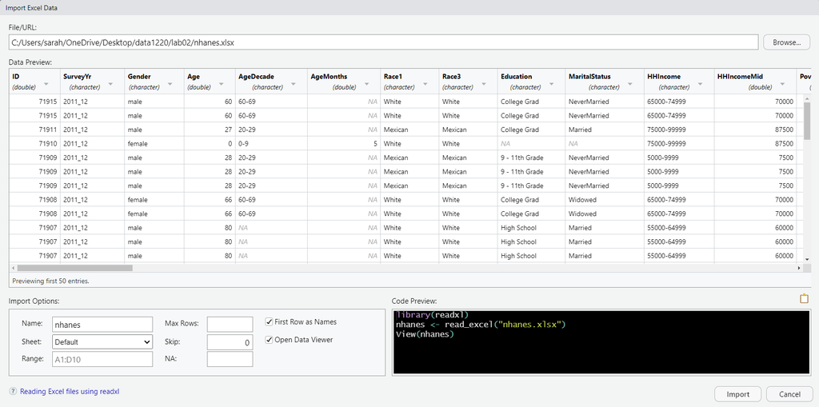

## Importing Files - Excel (Code)

[figure not shown]

## Load packages

- `readxl`: `read_xlsx()` function
- `Hmisc`: `describe()` function
- `dplyr`: `summarize()` and `select()` functions

## Codebook

- `Gender`: male or female
- `AlcoholYear`: count of the number of days in a year the subject drinks alcohol

## Research Question

*How many days in a year do men and women drink on average?*

- Point estimates by gender ($\bar{x}_m$ and $\bar{x}_f$, $s_m$ and $s_f$) and sample sizes ($n_m$ and $n_f$)
- Sampling distributions for sample statistics $\bar{x}_m \sim \text{N}\left(\mu_m, SE_{\bar{x}_m}\right)$ and $\bar{x}_f \sim \text{N}\left(\mu_f, SE_{\bar{x}_f}\right)$
- Confidence intervals for population means $\bar{x}_m \pm T_{\text{df}}^* \times \text{SE}_{\bar{x}_m}$ and $\bar{x}_f \pm T_{\text{df}}^* \times \text{SE}_{\bar{x}_f}$

## Research Question

*On average, do men and women drink the same number of days out of the year?*

- Point estimate of difference ($\bar{x}_m-\bar{x}_f$), standard deviations ($s_m$ and $s_f$) and sample sizes ($n_m$ and $n_f$)
- Sampling distribution $\bar{x}_m-\bar{x}_f \sim \text{N}\left(0, \text{SE}_{\bar{x}_m-\bar{x}_f}\right)$ for null hypothesis $H_0 \colon \mu_m-\mu_f=0$
- Test statistic $t$ for observed $\bar{x}_m-\bar{x}_f$ under null distribution $\bar{x}_m-\bar{x}_f \sim \text{N}\left(0, \text{SE}_{\bar{x}_m-\bar{x}_f}\right)$
- P-value for test statistic $t$ from Student’s $t$ distribution with degrees of freedom $\text{df}=\text{min}\left(n_m, n_f\right)-1$

## Research Question

*What proportion of days in a year do men and women drink on average?*

- Point estimates by gender ($\hat{p}_m$ and $\hat{p}_f$) and sample sizes ($n_m$ and $n_f$)
- Sampling distributions for sample statistics $\hat{p}_m \sim \text{N}\left(p_m, SE_{\hat{p}_m}\right)$ and $\hat{p}_f \sim \text{N}\left(p_f, SE_{\hat{p}_f}\right)$
- Confidence intervals for population means $\hat{p}_m \pm Z^* \times \text{SE}_{\hat{p}_m}$ and $\hat{p}_f \pm Z^* \times \text{SE}_{\hat{p}_f}$

## Research Question

*On average, do men and women drink the same proportion of days out of the year?*

- Point estimate of difference ($\hat{p}_m-\hat{p}_f$) and sample sizes ($n_m$ and $n_f$)
- Sampling distribution $\hat{p}_m-\hat{p}_f \sim \text{N}\left(0, \text{SE}_{\hat{p}_m-\hat{p}_f}\right)$ using $\hat{p}_{\text{pool}}$ for null hypothesis $H_0 \colon \mu_m-\mu_f=0$
- Test statistic $Z$ for observed $\hat{p}_m-\hat{p}_f$ under null distribution $\hat{p}_m-\hat{p}_f \sim \text{N}\left(0, \text{SE}_{\hat{p}_m-\hat{p}_f}\right)$
- P-value for test statistic $Z$ from the standard normal $Z$ distribution

DATA1220-55 Fall 2024, Class 29 | Updated: 2024-11-11 | [Canvas](https://canvas.jcu.edu/courses/36290) | [Campuswire](https://campuswire.com/c/G6427C531/feed)